# p8105_hw2_tz2659

Tracy Zhu

2024-10-02

```r
file_path <- "E:/Tracy/fall 2024/P8105 Data Science/p8105_hw2_tz2659/"
options(scipen=999) # Cancel scientific notation when describing dataset
```

## Problem 1

```r
library(readr)
library(dplyr)
nyc_subway_data <- read_csv("NYC_Transit_Subway_Entrance_And_Exit_Data.csv")
```

### Data overview

```r
n_rows <- nrow(nyc_subway_data)
n_cols <- ncol(nyc_subway_data)
head(nyc_subway_data)
```

```
## # A tibble: 6 × 32
##   Division Line     `Station Name` `Station Latitude` `Station Longitude` Route1
##   <chr>    <chr>    <chr>                       <dbl>               <dbl> <chr>
## 1 BMT      4 Avenue 25th St                      40.7               -74.0 R
## 2 BMT      4 Avenue 25th St                      40.7               -74.0 R
## 3 BMT      4 Avenue 36th St                      40.7               -74.0 N
## 4 BMT      4 Avenue 36th St                      40.7               -74.0 N
## 5 BMT      4 Avenue 36th St                      40.7               -74.0 N
## 6 BMT      4 Avenue 45th St                      40.6               -74.0 R
## # ℹ 26 more variables: Route2 <chr>, Route3 <chr>, Route4 <chr>, Route5 <chr>,
## #   Route6 <chr>, Route7 <chr>, Route8 <dbl>, Route9 <dbl>, Route10 <dbl>,
## #   Route11 <dbl>, `Entrance Type` <chr>, Entry <chr>, `Exit Only` <chr>,
## #   Vending <chr>, Staffing <chr>, `Staff Hours` <chr>, ADA <lgl>,
## #   `ADA Notes` <chr>, `Free Crossover` <lgl>, `North South Street` <chr>,
## #   `East West Street` <chr>, Corner <chr>, `Entrance Latitude` <dbl>,
## #   `Entrance Longitude` <dbl>, `Station Location` <chr>, …
```

```r
n_rows
```

```
## [1] 1868
```

```r
n_cols
```

```
## [1] 32
```

### Data cleaning

```r
# Select columns
cleaned_data <- nyc_subway_data %>%
  select(Line, `Station Name`, `Station Latitude`, `Station Longitude`,
         Route1, Route2, Route3, Entry, Vending, `Entrance Type`, ADA)

# Convert the entry variable from character to a logical variable
cleaned_data <- cleaned_data %>%
  mutate(Entry = ifelse(Entry == "YES", TRUE, FALSE))

head(cleaned_data)
```

```
## # A tibble: 6 × 11
##   Line     `Station Name` `Station Latitude` `Station Longitude` Route1 Route2
##   <chr>    <chr>                       <dbl>               <dbl> <chr>  <chr>
## 1 4 Avenue 25th St                      40.7               -74.0 R      <NA>
## 2 4 Avenue 25th St                      40.7               -74.0 R      <NA>
## 3 4 Avenue 36th St                      40.7               -74.0 N      R
## 4 4 Avenue 36th St                      40.7               -74.0 N      R
## 5 4 Avenue 36th St                      40.7               -74.0 N      R
## 6 4 Avenue 45th St                      40.6               -74.0 R      <NA>
## # ℹ 5 more variables: Route3 <chr>, Entry <lgl>, Vending <chr>,
## #   `Entrance Type` <chr>, ADA <lgl>
```

### How many distinct stations are there?

```r
dist_stations <- cleaned_data %>%
  distinct(`Station Name`, Line) %>%
  nrow()

dist_stations
```

```
## [1] 465
```

### How many stations are ADA compliant?

```r
ada_stations <- cleaned_data %>%
  filter(ADA == TRUE) %>%
  distinct(`Station Name`, Line) %>%
  nrow()

ada_stations
```

```
## [1] 84
```

```r
no_vend <- cleaned_data %>%
  filter(Vending == "NO") %>%
  nrow() / nrow(cleaned_data)

no_vend
```

```
## [1] 0.09796574
```

### How many distinct stations serve the A train? Of the stations that serve the A train, how many are ADA compliant?

```r
# Distinct stations that serve the A train
atrain_stations <- cleaned_data %>%
  filter(Route1 == "A" | Route2 == "A" | Route3 == "A") %>%
  distinct(`Station Name`, Line) %>%
  nrow()

# ADA compliant stations serving the A train
atrain_ada <- cleaned_data %>%
  filter((Route1 == "A" | Route2 == "A" | Route3 == "A") & ADA == TRUE) %>%
  distinct(`Station Name`, Line) %>%
  nrow()

atrain_stations
```

```
## [1] 60
```

```r
atrain_ada
```

```
## [1] 17
```

The dataset contains information on 1868 observations from NYC subway entrances and exits across different stations. There are 32 variables, primarily capturing details such as station name and line, station latitude and longitude, routes, entry permissions and vending machine availability, ADA compliance, etc.

After data cleaning, this dataset contains 1868 rows and 11 columns.

## Problem 2

*Mr. Trash Wheel*

```r
library(readxl)
library(dplyr)
library(janitor)
mr_df <- read_excel("202409 Trash Wheel Collection Data.xlsx",
                    sheet = "Mr. Trash Wheel", range = "A2:N653") |>
  janitor::clean_names() |>
  mutate(
    trash_wheel = "Mr. Trash Wheel",
    sports_balls = as.integer(round(sports_balls)), # Round sports balls to integer
    year = as.numeric(year)
  )
```

*Professor Trash Wheel*

```r
pf_df <- read_excel("202409 Trash Wheel Collection Data.xlsx",
                    sheet = "Professor Trash Wheel", range = "A2:M121") |>
  janitor::clean_names() |>
  mutate(
    trash_wheel = "Professor Trash Wheel"
  )
```

*Gwynnda Trash Wheel*

```r
gw_df <- read_excel("202409 Trash Wheel Collection Data.xlsx",
                                       sheet = "Gwynnda Trash Wheel", range = "A2:L265") |>
  janitor::clean_names() |>
  mutate(
    trash_wheel = "Gwynnda Trash Wheel"
  )
```

*Combine datasets*

```r
combined_df <- bind_rows(mr_df, pf_df, gw_df)

head(combined_df)
```

```
## # A tibble: 6 × 15
##   dumpster month  year date                weight_tons volume_cubic_yards
##      <dbl> <chr> <dbl> <dttm>                    <dbl>              <dbl>
## 1        1 May    2014 2014-05-16 00:00:00        4.31                 18
## 2        2 May    2014 2014-05-16 00:00:00        2.74                 13
## 3        3 May    2014 2014-05-16 00:00:00        3.45                 15
## 4        4 May    2014 2014-05-17 00:00:00        3.1                  15
## 5        5 May    2014 2014-05-17 00:00:00        4.06                 18
## 6        6 May    2014 2014-05-20 00:00:00        2.71                 13
## # ℹ 9 more variables: plastic_bottles <dbl>, polystyrene <dbl>,
## #   cigarette_butts <dbl>, glass_bottles <dbl>, plastic_bags <dbl>,
## #   wrappers <dbl>, sports_balls <int>, homes_powered <dbl>, trash_wheel <chr>
```

*Clean the combined dataset again*

```r
 # Filter out rows without dumpster-specific data
clean_df <- combined_df |>
  filter(!is.na(dumpster))
head(clean_df)
```

```
## # A tibble: 6 × 15
##   dumpster month  year date                weight_tons volume_cubic_yards
##      <dbl> <chr> <dbl> <dttm>                    <dbl>              <dbl>
## 1        1 May    2014 2014-05-16 00:00:00        4.31                 18
## 2        2 May    2014 2014-05-16 00:00:00        2.74                 13
## 3        3 May    2014 2014-05-16 00:00:00        3.45                 15
## 4        4 May    2014 2014-05-17 00:00:00        3.1                  15
## 5        5 May    2014 2014-05-17 00:00:00        4.06                 18
## 6        6 May    2014 2014-05-20 00:00:00        2.71                 13
## # ℹ 9 more variables: plastic_bottles <dbl>, polystyrene <dbl>,
## #   cigarette_butts <dbl>, glass_bottles <dbl>, plastic_bags <dbl>,
## #   wrappers <dbl>, sports_balls <int>, homes_powered <dbl>, trash_wheel <chr>
```

### Data description

The total dataset contains information on 1033 observations from three Trash Wheels: Mr. Trash Wheel, Professor Trash Wheel, and Gwynnda Trash Wheel. The dataset has key variables such as date of collection (`date`), total weight of trash collected (`weight_tons`), and number of plastic bottles (`plastic_bottles`) and cigarette butts (`cigarette_butts`) collected.

The total weight of trash collected by Professor Trash Wheel is 246.74 tons.

The total number of cigarette butts collected by Gwynnda in June of 2022 is 18120.

## Problem 3

```r
bakers <- read_csv('bakers.csv', na = c("NA", " ")) |>
  clean_names()|>
  janitor::clean_names() |>
  rename(baker = baker_name)
bakes <- read_csv('bakes.csv', na = c("NA", "N/A", " ")) |>
  clean_names()|>
  janitor::clean_names()
results <- read_csv('results.csv', skip = 2, na = c("NA", " ")) |>
  clean_names()|>
  janitor::clean_names()
viewers <- read_csv('viewers.csv', na = c("NA", " ")) |>
  clean_names()|>
  janitor::clean_names()
glimpse(bakers)
```

```
## Rows: 120
## Columns: 5
## $ baker            <chr> "Ali Imdad", "Alice Fevronia", "Alvin Magallanes", "A…
## $ series           <dbl> 4, 10, 6, 10, 7, 1, 9, 4, 2, 7, 3, 9, 7, 3, 5, 8, 4, …
## $ baker_age        <dbl> 25, 28, 37, 24, 25, 30, 30, 31, 31, 23, 63, 33, 31, 2…
## $ baker_occupation <chr> "Charity worker", "Geography teacher", "Nurse", "Fash…
## $ hometown         <chr> "Saltley, Birmingham", "Essex", "Bracknell, Berkshire…
```

```r
glimpse(bakes)
```

```
## Rows: 548
## Columns: 5
## $ series         <dbl> 1, 1, 1, 1, 1, 1, 1, 1, 1, 1, 1, 1, 1, 1, 1, 1, 1, 1, 1…
## $ episode        <dbl> 1, 1, 1, 1, 1, 1, 1, 1, 1, 1, 2, 2, 2, 2, 2, 2, 2, 2, 3…
## $ baker          <chr> "Annetha", "David", "Edd", "Jasminder", "Jonathan", "Le…
## $ signature_bake <chr> "Light Jamaican Black Cakewith Strawberries and Cream",…
## $ show_stopper   <chr> "Red, White & Blue Chocolate Cake with Cigarellos, Fres…
```

```r
glimpse(results)
```

```
## Rows: 1,136
## Columns: 5
## $ series    <dbl> 1, 1, 1, 1, 1, 1, 1, 1, 1, 1, 1, 1, 1, 1, 1, 1, 1, 1, 1, 1, …
## $ episode   <dbl> 1, 1, 1, 1, 1, 1, 1, 1, 1, 1, 2, 2, 2, 2, 2, 2, 2, 2, 2, 2, …
## $ baker     <chr> "Annetha", "David", "Edd", "Jasminder", "Jonathan", "Louise"…
## $ technical <dbl> 2, 3, 1, NA, 9, NA, 8, NA, 10, NA, 8, 6, 2, 1, 3, 5, 7, 4, N…
## $ result    <chr> "IN", "IN", "IN", "IN", "IN", "IN", "IN", "IN", "OUT", "OUT"…
```

```r
glimpse(viewers)
```

```
## Rows: 10
## Columns: 11
## $ episode   <dbl> 1, 2, 3, 4, 5, 6, 7, 8, 9, 10
## $ series_1  <dbl> 2.24, 3.00, 3.00, 2.60, 3.03, 2.75, NA, NA, NA, NA
## $ series_2  <dbl> 3.10, 3.53, 3.82, 3.60, 3.83, 4.25, 4.42, 5.06, NA, NA
## $ series_3  <dbl> 3.85, 4.60, 4.53, 4.71, 4.61, 4.82, 5.10, 5.35, 5.70, 6.74
## $ series_4  <dbl> 6.60, 6.65, 7.17, 6.82, 6.95, 7.32, 7.76, 7.41, 7.41, 9.45
## $ series_5  <dbl> 8.510, 8.790, 9.280, 10.250, 9.950, 10.130, 10.280, 9.023, 1…
## $ series_6  <dbl> 11.62, 11.59, 12.01, 12.36, 12.39, 12.00, 12.35, 11.09, 12.6…
## $ series_7  <dbl> 13.58, 13.45, 13.01, 13.29, 13.12, 13.13, 13.45, 13.26, 13.4…
## $ series_8  <dbl> 9.46, 9.23, 8.68, 8.55, 8.61, 8.61, 9.01, 8.95, 9.03, 10.04
## $ series_9  <dbl> 9.55, 9.31, 8.91, 8.88, 8.67, 8.91, 9.22, 9.69, 9.50, 10.34
## $ series_10 <dbl> 9.62, 9.38, 8.94, 8.96, 9.26, 8.70, 8.98, 9.19, 9.34, 10.05
```

```r
summary(bakers)
```

```
##     baker               series       baker_age     baker_occupation
##  Length:120         Min.   : 1.0   Min.   :17.00   Length:120
##  Class :character   1st Qu.: 3.0   1st Qu.:28.75   Class :character
##  Mode  :character   Median : 6.0   Median :34.00   Mode  :character
##                     Mean   : 5.6   Mean   :37.39
##                     3rd Qu.: 8.0   3rd Qu.:45.00
##                     Max.   :10.0   Max.   :71.00
##    hometown
##  Length:120
##  Class :character
##  Mode  :character
##
##
##
```

```r
summary(bakes)
```

```
##      series        episode          baker           signature_bake
##  Min.   :1.00   Min.   : 1.000   Length:548         Length:548
##  1st Qu.:3.00   1st Qu.: 2.000   Class :character   Class :character
##  Median :5.00   Median : 4.000   Mode  :character   Mode  :character
##  Mean   :4.81   Mean   : 4.192
##  3rd Qu.:7.00   3rd Qu.: 6.000
##  Max.   :8.00   Max.   :10.000
##  show_stopper
##  Length:548
##  Class :character
##  Mode  :character
##
##
##
```

```r
summary(results)
```

```
##      series          episode         baker             technical
##  Min.   : 1.000   Min.   : 1.00   Length:1136        Min.   : 1.000
##  1st Qu.: 4.000   1st Qu.: 3.00   Class :character   1st Qu.: 2.000
##  Median : 6.000   Median : 5.00   Mode  :character   Median : 4.000
##  Mean   : 5.838   Mean   : 5.31                      Mean   : 4.843
##  3rd Qu.: 8.000   3rd Qu.: 8.00                      3rd Qu.: 7.000
##  Max.   :10.000   Max.   :10.00                      Max.   :13.000
##                                                      NA's   :440
##     result
##  Length:1136
##  Class :character
##  Mode  :character
##
##
##
##
```

```r
summary(viewers)
```

```
##     episode         series_1        series_2        series_3
##  Min.   : 1.00   Min.   :2.240   Min.   :3.100   Min.   :3.850
##  1st Qu.: 3.25   1st Qu.:2.638   1st Qu.:3.583   1st Qu.:4.603
##  Median : 5.50   Median :2.875   Median :3.825   Median :4.765
##  Mean   : 5.50   Mean   :2.770   Mean   :3.951   Mean   :5.001
##  3rd Qu.: 7.75   3rd Qu.:3.000   3rd Qu.:4.293   3rd Qu.:5.287
##  Max.   :10.00   Max.   :3.030   Max.   :5.060   Max.   :6.740
##                  NA's   :4       NA's   :2
##     series_4        series_5         series_6        series_7
##  Min.   :6.600   Min.   : 8.510   Min.   :11.09   Min.   :13.01
##  1st Qu.:6.853   1st Qu.: 9.087   1st Qu.:11.71   1st Qu.:13.16
##  Median :7.245   Median :10.040   Median :12.18   Median :13.37
##  Mean   :7.354   Mean   :10.039   Mean   :12.31   Mean   :13.56
##  3rd Qu.:7.410   3rd Qu.:10.273   3rd Qu.:12.38   3rd Qu.:13.45
##  Max.   :9.450   Max.   :13.510   Max.   :15.05   Max.   :15.90
##
##     series_8         series_9        series_10
##  Min.   : 8.550   Min.   : 8.670   Min.   : 8.700
##  1st Qu.: 8.627   1st Qu.: 8.910   1st Qu.: 8.965
##  Median : 8.980   Median : 9.265   Median : 9.225
##  Mean   : 9.017   Mean   : 9.298   Mean   : 9.242
##  3rd Qu.: 9.180   3rd Qu.: 9.537   3rd Qu.: 9.370
##  Max.   :10.040   Max.   :10.340   Max.   :10.050
##
```

### Use `anti-join` to find who do not have corresponding records

```r
bakers_missing <- results |>
  anti_join(bakers, by = c("baker", "series"))
bakers_missing
```

```
## # A tibble: 1,136 × 5
##    series episode baker     technical result
##     <dbl>   <dbl> <chr>         <dbl> <chr>
##  1      1       1 Annetha           2 IN
##  2      1       1 David             3 IN
##  3      1       1 Edd               1 IN
##  4      1       1 Jasminder        NA IN
##  5      1       1 Jonathan          9 IN
##  6      1       1 Louise           NA IN
##  7      1       1 Miranda           8 IN
##  8      1       1 Ruth             NA IN
##  9      1       1 Lea              10 OUT
## 10      1       1 Mark             NA OUT
## # ℹ 1,126 more rows
```

```r
bakes_missing <- results |>
  anti_join(bakes, by = c("baker", "series"))
bakes_missing
```

```
## # A tibble: 258 × 5
##    series episode baker  technical result
##     <dbl>   <dbl> <chr>      <dbl> <chr>
##  1      2       1 Joanne        11 IN
##  2      2       2 Joanne        10 IN
##  3      2       3 Joanne         1 IN
##  4      2       4 Joanne         8 IN
##  5      2       5 Joanne         6 IN
##  6      2       6 Joanne         1 STAR BAKER
##  7      2       7 Joanne         3 IN
##  8      2       8 Joanne         1 WINNER
##  9      9       1 Antony        12 IN
## 10      9       1 Briony         2 IN
## # ℹ 248 more rows
```

```r
results_missing <- results |>
  anti_join(results, by = c("baker", "series"))
results_missing
```

```
## # A tibble: 0 × 5
## # ℹ 5 variables: series <dbl>, episode <dbl>, baker <chr>, technical <dbl>,
## #   result <chr>
```

### Merge datasets

```r
# Keep first name to merge
library(tidyverse)
bakers = mutate(bakers, baker = word(baker, 1))

# Merge to final dataset
final_df = full_join(bakers, bakes, by = c("baker", "series")) |>
  full_join(results, by = c("baker", "episode", "series")) |>
  select(series, episode, baker, baker_age, baker_occupation, hometown, signature_bake, show_stopper, technical, result)

write_csv(final_df, "final_df") # Save the merged dataset
```

### Analyze dataset

Viewership per season

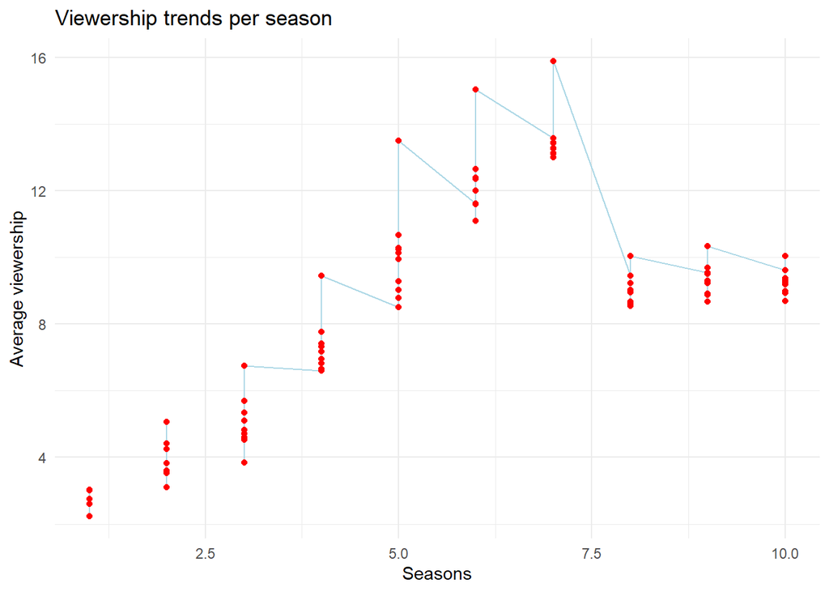

```r
library(ggplot2)

viewers_long <- viewers |>
  pivot_longer(cols = starts_with("series_"),
               names_to = "series",
               values_to = "viewership") |>
  mutate(series = as.numeric(str_remove(series, "series_")))

ggplot(viewers_long, aes(x = series, y = viewership)) +
  geom_line(color = "lightblue") +
  geom_point(color = "red") +
  labs(title = "Viewership trends per season",
       x = "Seasons",
       y = "Average viewership") +
  theme_minimal()
```

Technical performance vs result

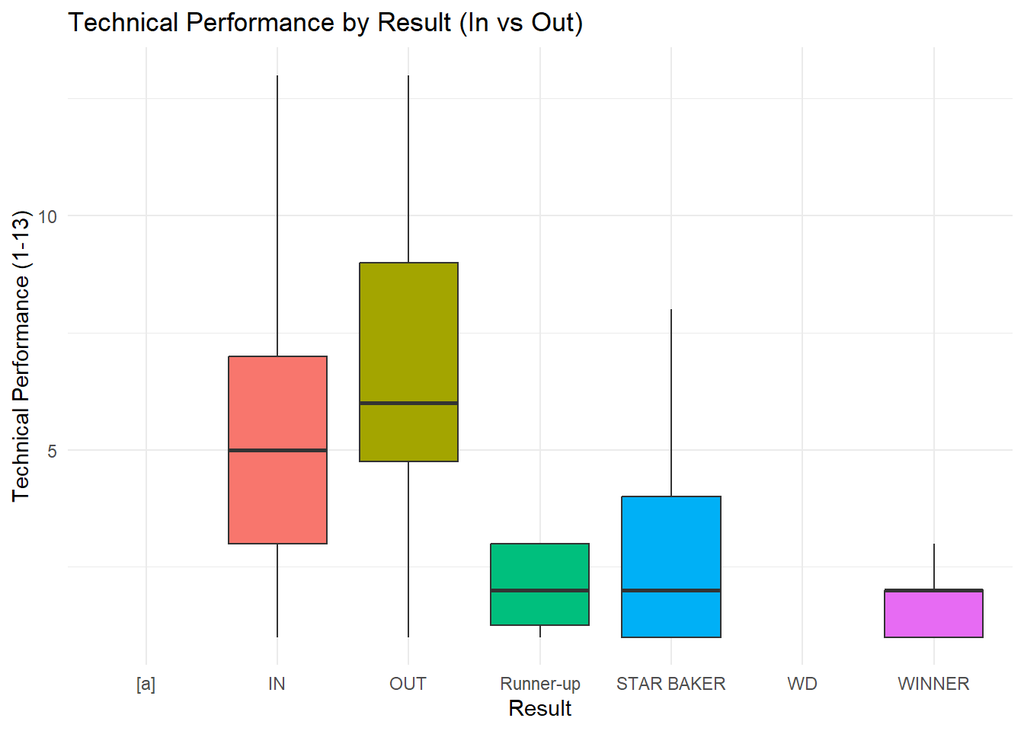

```r
cleaned_final_df <- final_df |> drop_na(result)

# Box plot of technical scores by result ("in" vs "out")
ggplot(cleaned_final_df, aes(x = result, y = technical, fill = result)) +
  geom_boxplot() +
  labs(title = "Technical Performance by Result (In vs Out)",
       x = "Result",
       y = "Technical Performance (1-13)") +
  theme_minimal() +
  theme(legend.position = "none")  # Remove legend since the result is on the x-axis
```

Technical Performance 1-13 shows the range of technical performance scores for each result. A lower score means better performance.

### Create a reader-friendly table showing the star baker or winner of each episode in Seasons 5 through 10. Comment on this table – were there any predictable overall winners? Any surprises?

```r
# Filter the data for Seasons 5 through 10 and focus on Star Baker and Winner results
star_baker_table <- final_df |>
  filter(series >= 5 & series <= 10) |>
  filter(result %in% c("STAR BAKER", "WINNER")) |>
  select(series, episode, baker, result) |>
  arrange(series, episode)

knitr::kable(star_baker_table,
             caption = "Star Baker and Winner for Each Episode in Seasons 5 through 10",
             col.names = c("Season", "Episode", "Baker", "Result"))
```

Star Baker and Winner for Each Episode in Seasons 5 through 10

| Season | Episode | Baker | Result |
| --- | --- | --- | --- |
| 5 | 1 | Nancy | STAR BAKER |
| 5 | 2 | Richard | STAR BAKER |
| 5 | 3 | Luis | STAR BAKER |
| 5 | 4 | Richard | STAR BAKER |
| 5 | 5 | Kate | STAR BAKER |
| 5 | 6 | Chetna | STAR BAKER |
| 5 | 7 | Richard | STAR BAKER |
| 5 | 8 | Richard | STAR BAKER |
| 5 | 9 | Richard | STAR BAKER |
| 5 | 10 | Nancy | WINNER |
| 6 | 1 | Marie | STAR BAKER |
| 6 | 2 | Ian | STAR BAKER |
| 6 | 3 | Ian | STAR BAKER |
| 6 | 4 | Ian | STAR BAKER |
| 6 | 5 | Nadiya | STAR BAKER |
| 6 | 6 | Mat | STAR BAKER |
| 6 | 7 | Tamal | STAR BAKER |
| 6 | 8 | Nadiya | STAR BAKER |
| 6 | 9 | Nadiya | STAR BAKER |
| 6 | 10 | Nadiya | WINNER |
| 7 | 1 | Jane | STAR BAKER |
| 7 | 2 | Candice | STAR BAKER |
| 7 | 3 | Tom | STAR BAKER |
| 7 | 4 | Benjamina | STAR BAKER |
| 7 | 5 | Candice | STAR BAKER |
| 7 | 6 | Tom | STAR BAKER |
| 7 | 7 | Andrew | STAR BAKER |
| 7 | 8 | Candice | STAR BAKER |
| 7 | 9 | Andrew | STAR BAKER |
| 7 | 10 | Candice | WINNER |
| 8 | 1 | Steven | STAR BAKER |
| 8 | 2 | Steven | STAR BAKER |
| 8 | 3 | Julia | STAR BAKER |
| 8 | 4 | Kate | STAR BAKER |
| 8 | 5 | Sophie | STAR BAKER |
| 8 | 6 | Liam | STAR BAKER |
| 8 | 7 | Steven | STAR BAKER |
| 8 | 8 | Stacey | STAR BAKER |
| 8 | 9 | Sophie | STAR BAKER |
| 8 | 10 | Sophie | WINNER |
| 9 | 1 | Manon | STAR BAKER |
| 9 | 2 | Rahul | STAR BAKER |
| 9 | 3 | Rahul | STAR BAKER |
| 9 | 4 | Dan | STAR BAKER |
| 9 | 5 | Kim-Joy | STAR BAKER |
| 9 | 6 | Briony | STAR BAKER |
| 9 | 7 | Kim-Joy | STAR BAKER |
| 9 | 8 | Ruby | STAR BAKER |
| 9 | 9 | Ruby | STAR BAKER |
| 9 | 10 | Rahul | WINNER |
| 10 | 1 | Michelle | STAR BAKER |
| 10 | 2 | Alice | STAR BAKER |
| 10 | 3 | Michael | STAR BAKER |
| 10 | 4 | Steph | STAR BAKER |
| 10 | 5 | Steph | STAR BAKER |
| 10 | 6 | Steph | STAR BAKER |
| 10 | 7 | Henry | STAR BAKER |
| 10 | 8 | Steph | STAR BAKER |
| 10 | 9 | Alice | STAR BAKER |
| 10 | 10 | David | WINNER |

Predictable results:

Seasons 6, 7, and 9 show predictable outcomes, where the bakers who won multiple Star Baker titles (Nadiya, Candice, Rahul) went on to win the entire season.

Surprising results:

Season 5: Richard’s 5 Star Baker titles didn’t make him to a final victory. Season 10: David didn’t have any Star Baker title, but he wins in the end. Steph’s consistent dominance throughout the season, with 4 titles, made her the likely candidate for the winner, but she didn’t win.

In general, while strong performances often correlate with final success, surprises still happen.

### Averages of viewership for series 1 and 5

```r
av_1 = mean(pull(viewers, series_1), na.rm = TRUE)
av_5 = mean(pull(viewers, series_5), na.rm = TRUE)
av_1
```

```
## [1] 2.77
```

```r
av_5
```

```
## [1] 10.0393
```

The average viewership for series 1 and 5 are 2.77 and 10.0393